# wrangle_act

#### Project Overview:

WeRateDogs is a Twitter account that rates people's dogs with a humorous comment about the dog. These ratings almost always have a denominator of 10. But the numerators are almost always greater than 10 with ratings such as 11/10, 12/10, 13/10, etc. Why? Because "they're good dogs Brent."

In our project, the dataset that we will be wrangling is the tweet archive of WeRateDogs.

All data in one table makes all data accessible, user-friendly and useful for further data analysis.

The Data Wrangling is done in the following phases:

- Gathering Phase
- Assessing Phase
- Cleaning Phase

Storing, Analyzing and Visualising the data is done as below:

- Storing
- Insights & Visualizations

```python
# Let us import all the necessary libraries
import numpy as np
import pandas as pd
import requests
import os
import tweepy
from tweepy import OAuthHandler
import json
import re
from functools import reduce
from timeit import default_timer as timer
import matplotlib.pyplot as plt
import seaborn as sns
%matplotlib inline
# plt.rcParams['figure.figsize'] = [15, 8]
```

## Gathering Phase

In this phase, we will be gathering our data and storing them into 3 seperate dataframes namely:

- twitter_archive
- twitter_image_pred
- twitter_apidata

```python
# Importing data from the .csv file to create our twitter_archive dataframe
twitter_archive= pd.read_csv('twitter-archive-enhanced.csv')
twitter_archive.head(3)
```

|  | tweet_id | in_reply_to_status_id | in_reply_to_user_id | timestamp | source | text | retweeted_status_id | retweeted_status_user_id | retweeted_status_timestamp | expanded_urls | rating_numerator | rating_denominator | name | doggo | floofer | pupper | puppo |
| --- | --- | --- | --- | --- | --- | --- | --- | --- | --- | --- | --- | --- | --- | --- | --- | --- | --- |
| 0 | 892420643555336193 | NaN | NaN | 2017-08-01 16:23:56 +0000 | <a href="http://twitter.com/download/iphone" r... | This is Phineas. He's a mystical boy. Only eve... | NaN | NaN | NaN | https://twitter.com/dog_rates/status/892420643... | 13 | 10 | Phineas | None | None | None | None |
| 1 | 892177421306343426 | NaN | NaN | 2017-08-01 00:17:27 +0000 | <a href="http://twitter.com/download/iphone" r... | This is Tilly. She's just checking pup on you.... | NaN | NaN | NaN | https://twitter.com/dog_rates/status/892177421... | 13 | 10 | Tilly | None | None | None | None |
| 2 | 891815181378084864 | NaN | NaN | 2017-07-31 00:18:03 +0000 | <a href="http://twitter.com/download/iphone" r... | This is Archie. He is a rare Norwegian Pouncin... | NaN | NaN | NaN | https://twitter.com/dog_rates/status/891815181... | 12 | 10 | Archie | None | None | None | None |

```python
# The file,image_predictions.tsv is downloaded from the Udacity servers using the Requests library programatically.
url= 'https://d17h27t6h515a5.cloudfront.net/topher/2017/August/599fd2ad_image-predictions/image-predictions.tsv'
response= requests.get(url)
response
```

```
<Response [200]>
```

An output of <Response [200]> shows our response code has worked correctly.

```python
# Writing the contents of the response to a file called image_predictions.tsv
with open('image_predictions.tsv', mode='wb') as file:
        file.write(response.content)

# Creating our twitter_image_pred dataframe
twitter_image_pred= pd.read_csv('image_predictions.tsv', sep='\t')
twitter_image_pred.head(3)
```

|  | tweet_id | jpg_url | img_num | p1 | p1_conf | p1_dog | p2 | p2_conf | p2_dog | p3 | p3_conf | p3_dog |
| --- | --- | --- | --- | --- | --- | --- | --- | --- | --- | --- | --- | --- |
| 0 | 666020888022790149 | https://pbs.twimg.com/media/CT4udn0WwAA0aMy.jpg | 1 | Welsh_springer_spaniel | 0.465074 | True | collie | 0.156665 | True | Shetland_sheepdog | 0.061428 | True |
| 1 | 666029285002620928 | https://pbs.twimg.com/media/CT42GRgUYAA5iDo.jpg | 1 | redbone | 0.506826 | True | miniature_pinscher | 0.074192 | True | Rhodesian_ridgeback | 0.072010 | True |
| 2 | 666033412701032449 | https://pbs.twimg.com/media/CT4521TWwAEvMyu.jpg | 1 | German_shepherd | 0.596461 | True | malinois | 0.138584 | True | bloodhound | 0.116197 | True |

Querying the Twitter API using Python's Tweepy library to get the Retweet count and Favourite Count into a file called tweet_json.txt

```python
consumer_key = 'HIDDEN'
consumer_secret = 'HIDDEN'
access_token = 'HIDDEN'
access_secret = 'HIDDEN'

auth = OAuthHandler(consumer_key, consumer_secret)
auth.set_access_token(access_token, access_secret)

api = tweepy.API(auth, wait_on_rate_limit=True)
tweet_ids = twitter_archive.tweet_id.values
```

```python
# Querying Twitter's API for JSON data for each tweet ID in the Twitter archive
count = 0
fails_dict = {}
start = timer()
# Save each tweet's returned JSON as a new line in a .txt file
with open('tweet_json.txt', 'w') as outfile:
    # This loop will likely take 20-30 minutes to run because of Twitter's rate limit
    for tweet_id in tweet_ids:
        count += 1
        print(str(count) + ": " + str(tweet_id))
        try:
            tweet = api.get_status(tweet_id, tweet_mode='extended')
            print("Success")
            json.dump(tweet._json, outfile)
            outfile.write('\n')
        except tweepy.TweepError as e:
            print("Fail")
            fails_dict[tweet_id] = e
            pass
end = timer()
print(end - start)
print(fails_dict)
```

[output not shown]

[output cut: 4659 more lines]

[output not shown]

```python
# Reading the tweet_json.txt file line by line,loading all the relevant details from the file to a dictionary called
# tweets_dict and appending the same into a list called tweets_list
tweets_list =[]

with open('tweet_json.txt','r') as json_file:
    for line in json_file.readlines():

        tweets_dict = {}
        tweets_json = json.loads(line)
        tweets_dict['retweet_count'] = tweets_json['retweet_count']
        tweets_dict['favorite_count'] = tweets_json['favorite_count']
        tweets_dict['tweet_id']= tweets_json['id']

        tweets_list.append(tweets_dict)
```

```python
# Creating our twitter_apidata dataframe from tweets_list
twitter_apidata= pd.DataFrame(tweets_list, columns= ['tweet_id','favorite_count','retweet_count'])
twitter_apidata.head(3)
```

|  | tweet_id | favorite_count | retweet_count |
| --- | --- | --- | --- |
| 0 | 892420643555336193 | 37217 | 7975 |
| 1 | 892177421306343426 | 32012 | 5919 |
| 2 | 891815181378084864 | 24100 | 3911 |

## Assessing Phase

Let us use the .info(),.isnull(),.duplicated() and .sample methods to help us assess our dataframes on a high level.

```python
twitter_archive.info()
```

```
<class 'pandas.core.frame.DataFrame'>
RangeIndex: 2356 entries, 0 to 2355
Data columns (total 17 columns):
tweet_id                      2356 non-null int64
in_reply_to_status_id         78 non-null float64
in_reply_to_user_id           78 non-null float64
timestamp                     2356 non-null object
source                        2356 non-null object
text                          2356 non-null object
retweeted_status_id           181 non-null float64
retweeted_status_user_id      181 non-null float64
retweeted_status_timestamp    181 non-null object
expanded_urls                 2297 non-null object
rating_numerator              2356 non-null int64
rating_denominator            2356 non-null int64
name                          2356 non-null object
doggo                         2356 non-null object
floofer                       2356 non-null object
pupper                        2356 non-null object
puppo                         2356 non-null object
dtypes: float64(4), int64(3), object(10)
memory usage: 313.0+ KB
```

```python
twitter_archive.isnull().sum().sort_values(ascending= False)
```

```
in_reply_to_status_id         2278
in_reply_to_user_id           2278
retweeted_status_timestamp    2175
retweeted_status_user_id      2175
retweeted_status_id           2175
expanded_urls                   59
timestamp                        0
source                           0
text                             0
puppo                            0
pupper                           0
rating_numerator                 0
rating_denominator               0
name                             0
doggo                            0
floofer                          0
tweet_id                         0
dtype: int64
```

The two columns in_reply_to_status_id and in_reply_to_user_id have the highest number of null values. We will remove them since they are not needed for our data analysis.

```python
sum(twitter_archive.duplicated())
```

```
0
```

The twitter_archive dataframe doesn't have any duplicated values

```python
twitter_archive.sample(3)
```

|  | tweet_id | in_reply_to_status_id | in_reply_to_user_id | timestamp | source | text | retweeted_status_id | retweeted_status_user_id | retweeted_status_timestamp | expanded_urls | rating_numerator | rating_denominator | name | doggo | floofer | pupper | puppo |
| --- | --- | --- | --- | --- | --- | --- | --- | --- | --- | --- | --- | --- | --- | --- | --- | --- | --- |
| 1581 | 687124485711986689 | NaN | NaN | 2016-01-13 04:10:18 +0000 | <a href="http://twitter.com/download/iphone" r... | Say hello to Samson. He's a Firecracker Häagen... | NaN | NaN | NaN | https://twitter.com/dog_rates/status/687124485... | 11 | 10 | Samson | None | None | None | None |
| 838 | 767500508068192258 | NaN | NaN | 2016-08-21 23:15:55 +0000 | <a href="http://twitter.com/download/iphone" r... | This is Louie. He's making quite a h*ckin mess... | NaN | NaN | NaN | https://twitter.com/dog_rates/status/767500508... | 12 | 10 | Louie | None | None | None | None |
| 1606 | 685667379192414208 | NaN | NaN | 2016-01-09 03:40:16 +0000 | <a href="http://twitter.com/download/iphone" r... | This is Marty. He has no idea what happened he... | NaN | NaN | NaN | https://twitter.com/dog_rates/status/685667379... | 9 | 10 | Marty | None | None | pupper | None |

```python
# Now let's explore the twitter_image_pred dataframe using the same dataframe methods
twitter_image_pred.info()
```

```
<class 'pandas.core.frame.DataFrame'>
RangeIndex: 2075 entries, 0 to 2074
Data columns (total 12 columns):
tweet_id    2075 non-null int64
jpg_url     2075 non-null object
img_num     2075 non-null int64
p1          2075 non-null object
p1_conf     2075 non-null float64
p1_dog      2075 non-null bool
p2          2075 non-null object
p2_conf     2075 non-null float64
p2_dog      2075 non-null bool
p3          2075 non-null object
p3_conf     2075 non-null float64
p3_dog      2075 non-null bool
dtypes: bool(3), float64(3), int64(2), object(4)
memory usage: 152.1+ KB
```

```python
sum(twitter_image_pred.duplicated())
```

```
0
```

The twitter_image_pred dataframe doesn't seem to have any null or duplicated entries.

```python
twitter_image_pred.sample(3)
```

|  | tweet_id | jpg_url | img_num | p1 | p1_conf | p1_dog | p2 | p2_conf | p2_dog | p3 | p3_conf | p3_dog |
| --- | --- | --- | --- | --- | --- | --- | --- | --- | --- | --- | --- | --- |
| 600 | 679736210798047232 | https://pbs.twimg.com/media/CW7oelWWcAAhyzz.jpg | 1 | French_bulldog | 0.319139 | True | Chihuahua | 0.154088 | True | Cardigan | 0.117688 | True |
| 599 | 679729593985699840 | https://pbs.twimg.com/media/CW7iddWUsAElUC0.jpg | 1 | wallaby | 0.164215 | False | West_Highland_white_terrier | 0.093515 | True | ashcan | 0.067278 | False |
| 987 | 707741517457260545 | https://pbs.twimg.com/media/CdJnJ1dUEAARNcf.jpg | 1 | whippet | 0.738371 | True | Italian_greyhound | 0.191789 | True | American_Staffordshire_terrier | 0.020126 | True |

```python
# Now let's explore the twitter_apidata dataframe using the same dataframe methods
twitter_apidata.info()
```

```
<class 'pandas.core.frame.DataFrame'>
RangeIndex: 2333 entries, 0 to 2332
Data columns (total 3 columns):
tweet_id          2333 non-null int64
favorite_count    2333 non-null int64
retweet_count     2333 non-null int64
dtypes: int64(3)
memory usage: 54.8 KB
```

```python
twitter_apidata.isnull().sum()
```

```
tweet_id          0
favorite_count    0
retweet_count     0
dtype: int64
```

```python
sum(twitter_apidata.duplicated())
```

```
0
```

The twitter_apidata dataframe doesn't seem to have any null or duplicated entries.

```python
twitter_apidata.sample(3)
```

|  | tweet_id | favorite_count | retweet_count |
| --- | --- | --- | --- |
| 1177 | 716791146589110272 | 7445 | 1564 |
| 997 | 746790600704425984 | 5007 | 1642 |
| 1218 | 712085617388212225 | 3331 | 495 |

```python
# Let us save our twitter_apidata dataframe into a .csv file.
twitter_apidata.to_csv('apidata_csv',index= False)
```

Let us analyse each of the dataframes in detail and record the respective Quality and Tidiness issues that need to be tackled in our data analysis.

```python
twitter_archive.rating_numerator.value_counts().sort_index()
```

```
0         2
1         9
2         9
3        19
4        17
5        37
6        32
7        55
8       102
9       158
10      461
11      464
12      558
13      351
14       54
```

[output cut: 26 more lines]

```python
twitter_archive.rating_denominator.value_counts().sort_index()
```

```
0         1
2         1
7         1
10     2333
11        3
15        1
16        1
20        2
40        1
50        3
70        1
80        2
90        1
110       1
120       1
130       1
150       1
170       1
Name: rating_denominator, dtype: int64
```

```python
twitter_archive.name.value_counts()
```

```
None            745
a                55
Charlie          12
Oliver           11
Cooper           11
Lucy             11
Penny            10
Lola             10
Tucker           10
Winston           9
Bo                9
Sadie             8
the               8
an                7
Bailey            7
Daisy             7
Buddy             7
Toby              7
Milo              6
Rusty             6
Bella             6
Koda              6
Dave              6
Scout             6
Stanley           6
Oscar             6
Leo               6
Jack              6
Jax               6
Oakley            5
               ...
unacceptable      1
Margo             1
Lolo              1
Harnold           1
Todo              1
Carter            1
Tuck              1
Genevieve         1
Ricky             1
Amber             1
by                1
Butters           1
Bradlay           1
Gerbald           1
Trigger           1
Buddah            1
Jennifur          1
Spark             1
Walker            1
Clyde             1
Kuyu              1
Heinrich          1
Ziva              1
Caryl             1
Marvin            1
Stormy            1
Tycho             1
Mojo              1
Lilli             1
Liam              1
Name: name, Length: 957, dtype: int64
```

Let us calculate the maximum and minimum values of the image prediction algorithms confidence levels for each of it's predictions respectively.

```python
twitter_image_pred.p1_conf.max()*100, twitter_image_pred.p2_conf.max()*100, twitter_image_pred.p3_conf.max()*100
```

```
(100.0, 48.80140000000001, 27.341900000000003)
```

```python
twitter_image_pred.p1_conf.min()*100, twitter_image_pred.p2_conf.min()*100, twitter_image_pred.p3_conf.min()*100
```

```
(4.43334, 1.0113e-06, 1.74017e-08)
```

#### Assessing Data for Quality Issues:

twitter_archive dataframe:

1) The columns in_reply_to_status_id, in_reply_to_user_id are not very useful in our data analysis. Also, the columns related to retweets will not contain any data once tidied. Hence can be removed.  
2) The timestamp column is of object(string) datatype.  
3) The name column contains 'a','an','the' etc as names instead of the actual names.  
4) The source column can just have the source of the tweet instead of the complete url.  
5) The text column contains urls which can be extracted into a seperate column.  
6) The rating denominator is not equal to 10 in 23 rows.  
7) The rating_numerator has values way higher than 14 (allowed as per the WeRateDogs' account rating system).  
8) To create one standardized rating column for every row.  
9) (a)To change the datatypes of the newly created columns.  
(b)The tweet_id column is of integer datatype in all the three dataframes. Once all the dataframes are merged, the datatype of this column can be changed in one place.

twitter_image_pred dataframe:  
9) (b)The tweet_id column is of integer datatype.  
10) The dataframe has many columns for image_prediction. We need to clean it.

twitter_apidata dataframe:  
9) (b)The tweet_id column is of integer datatype.

#### Assessing Data for Tidiness Issues:

1) We only want the original ratings. Hence we need to remove all the retweets (all the non-null values) from the retweet_status_id and related columns.  
2) The single dog stage variable is represented in 4 different columns.  
3) All the three dataframes need to be merged on tweet_id to create one master dataframe.

## Cleaning Phase

```python
# Let us copy all the dataframes into new dataframes to work on respectively
archive_clean= twitter_archive.copy()
images_clean= twitter_image_pred.copy()
apidata_clean= twitter_apidata.copy()
```

## Define: Tidiness Issue 1

Let us remove all the 181 rows of non-null(retweet)data under the retweeted_status_id and retweeted_status_user_id columns. We assign the dataframe with all null values for the retweeted_status_id to our archive_clean.

## Code

```python
archive_clean= archive_clean[archive_clean.retweeted_status_id.isnull()]
```

## Test

```python
# All the retweets have been removed from the archive_clean.
archive_clean.info()
```

```
<class 'pandas.core.frame.DataFrame'>
Int64Index: 2175 entries, 0 to 2355
Data columns (total 17 columns):
tweet_id                      2175 non-null int64
in_reply_to_status_id         78 non-null float64
in_reply_to_user_id           78 non-null float64
timestamp                     2175 non-null object
source                        2175 non-null object
text                          2175 non-null object
retweeted_status_id           0 non-null float64
retweeted_status_user_id      0 non-null float64
retweeted_status_timestamp    0 non-null object
expanded_urls                 2117 non-null object
rating_numerator              2175 non-null int64
rating_denominator            2175 non-null int64
name                          2175 non-null object
doggo                         2175 non-null object
floofer                       2175 non-null object
pupper                        2175 non-null object
puppo                         2175 non-null object
dtypes: float64(4), int64(3), object(10)
memory usage: 305.9+ KB
```

## Define: Quality Issue 1

Since we have removed all the non-null values of retweeted_status_id the columns retweeted_status_id,retweeted_status_user_id and retweeted_timestamp all only contain null values. We no longer need them and hence we can drop them. Also, we do not need the in_reply_to_status_id and in_reply_to_user_id columns for our data analysis and hence drop them too.

## Code

```python
cols= ['retweeted_status_id','retweeted_status_user_id','retweeted_status_timestamp','in_reply_to_status_id',
      'in_reply_to_user_id']
archive_clean.drop(cols, axis=1, inplace= True)
```

## Test

```python
# All the unnecessary columns have been removed from archive_clean.
archive_clean.info()
```

```
<class 'pandas.core.frame.DataFrame'>
Int64Index: 2175 entries, 0 to 2355
Data columns (total 12 columns):
tweet_id              2175 non-null int64
timestamp             2175 non-null object
source                2175 non-null object
text                  2175 non-null object
expanded_urls         2117 non-null object
rating_numerator      2175 non-null int64
rating_denominator    2175 non-null int64
name                  2175 non-null object
doggo                 2175 non-null object
floofer               2175 non-null object
pupper                2175 non-null object
puppo                 2175 non-null object
dtypes: int64(3), object(9)
memory usage: 220.9+ KB
```

## Define: Quality Issue 2

Let us slice the timestamp to our required format and then change it's datatype to datetime in the archive_clean dataframe.

## Code

```python
archive_clean['timestamp']= archive_clean.timestamp.str.slice(start=0,stop= -6)
archive_clean['timestamp']= pd.to_datetime(archive_clean['timestamp'], format= "%Y-%m-%d %H:%M:%S")
```

## Test

```python
archive_clean.info()
```

```
<class 'pandas.core.frame.DataFrame'>
Int64Index: 2175 entries, 0 to 2355
Data columns (total 12 columns):
tweet_id              2175 non-null int64
timestamp             2175 non-null datetime64[ns]
source                2175 non-null object
text                  2175 non-null object
expanded_urls         2117 non-null object
rating_numerator      2175 non-null int64
rating_denominator    2175 non-null int64
name                  2175 non-null object
doggo                 2175 non-null object
floofer               2175 non-null object
pupper                2175 non-null object
puppo                 2175 non-null object
dtypes: datetime64[ns](1), int64(3), object(8)
memory usage: 220.9+ KB
```

```python
archive_clean.timestamp.sample(3)
```

```
2167   2015-11-25 03:39:17
1542   2016-01-20 00:03:21
2141   2015-11-26 21:36:12
Name: timestamp, dtype: datetime64[ns]
```

## Define: Tidiness Issue 2

Let us shrink the four dog_stage variables of doggo, floofer, pupper and puppo into one dog_stage variable column and add NaNs to values which do not belong to either of them.

## Code

```python
archive_clean[['text','doggo','floofer','pupper','puppo']].head(5)
```

|  | text | doggo | floofer | pupper | puppo |
| --- | --- | --- | --- | --- | --- |
| 0 | This is Phineas. He's a mystical boy. Only eve... | None | None | None | None |
| 1 | This is Tilly. She's just checking pup on you.... | None | None | None | None |
| 2 | This is Archie. He is a rare Norwegian Pouncin... | None | None | None | None |
| 3 | This is Darla. She commenced a snooze mid meal... | None | None | None | None |
| 4 | This is Franklin. He would like you to stop ca... | None | None | None | None |

```python
archive_clean['dog_stage']= archive_clean['text'].str.extract('(doggo|floofer|pupper|puppo)', expand= False)
```

## Test

```python
archive_clean[['dog_stage','doggo','floofer','pupper','puppo']].head(20)
```

|  | dog_stage | doggo | floofer | pupper | puppo |
| --- | --- | --- | --- | --- | --- |
| 0 | NaN | None | None | None | None |
| 1 | NaN | None | None | None | None |
| 2 | NaN | None | None | None | None |
| 3 | NaN | None | None | None | None |
| 4 | NaN | None | None | None | None |
| 5 | NaN | None | None | None | None |
| 6 | NaN | None | None | None | None |
| 7 | NaN | None | None | None | None |
| 8 | NaN | None | None | None | None |
| 9 | doggo | doggo | None | None | None |
| 10 | NaN | None | None | None | None |
| 11 | NaN | None | None | None | None |
| 12 | puppo | None | None | None | puppo |
| 13 | NaN | None | None | None | None |
| 14 | puppo | None | None | None | puppo |
| 15 | NaN | None | None | None | None |
| 16 | NaN | None | None | None | None |
| 17 | NaN | None | None | None | None |
| 18 | NaN | None | None | None | None |
| 20 | NaN | None | None | None | None |

```python
# Let us drop all the dog_stage variable columns.
archive_clean.drop(['doggo','floofer','pupper','puppo'], axis=1, inplace=True)
```

## Define: Quality Issue 3

The name column has a lot of values carrying 'None'. We also observe there are lowercase alphabets like 'a','an','the' etc for the rows where dog names are absent. We will replace all of these with NaN. Some names are not extracted accurately displaying just 'O' for "O'Malley". We will manually fix this one.

## Code

```python
# Let us get all the lowercase names into a list called lower_names.
lower_names=[]
for name in archive_clean['name']:
    if name[0].islower() and name not in lower_names:
        lower_names.append(name)
print(lower_names)
```

```
['such', 'a', 'quite', 'not', 'one', 'incredibly', 'very', 'my', 'his', 'an', 'actually', 'just', 'getting', 'mad', 'this', 'unacceptable', 'all', 'old', 'infuriating', 'the', 'by', 'officially', 'life', 'light', 'space']
```

```python
# Replacing all 'None's with a NaN
archive_clean['name'].replace('None', np.nan, inplace = True)

# Replacing all names that start with a lowercase letter with a NaN
archive_clean['name'].replace(lower_names, np.nan, inplace= True)

# Replacing the name 'O' with "O'Malley"
archive_clean['name'].replace('O', "O'Malley", inplace = True)
```

## Test

```python
archive_clean.name.value_counts()
```

```
Lucy          11
Charlie       11
Cooper        10
Oliver        10
Tucker         9
Penny          9
Sadie          8
Lola           8
Winston        8
Toby           7
Daisy          7
Bo             6
Koda           6
Jax            6
Stanley        6
Bailey         6
Oscar          6
Bella          6
Milo           5
Leo            5
Rusty          5
Dave           5
Bentley        5
Buddy          5
Louis          5
Chester        5
Scout          5
George         4
Brody          4
Gus            4
              ..
Godzilla       1
Lance          1
Carbon         1
Kramer         1
Brandonald     1
Corey          1
Humphrey       1
Shooter        1
Augie          1
Jett           1
Noosh          1
Alexander      1
Happy          1
Harvey         1
Willie         1
Kevon          1
Alfy           1
Monty          1
Duchess        1
Cedrick        1
Pinot          1
Goose          1
Sobe           1
Pippin         1
General        1
Ken            1
Tayzie         1
Fletcher       1
Ike            1
Mac            1
Name: name, Length: 930, dtype: int64
```

## Define: Quality Issue 4

Let us replace the complete url in the source column with only the source of the tweet.

## Code

```python
archive_clean.source= archive_clean.source.str.split(r'<|>').str[2]
```

## Test

```python
archive_clean.source.value_counts()
```

```
Twitter for iPhone     2042
Vine - Make a Scene      91
Twitter Web Client       31
TweetDeck                11
Name: source, dtype: int64
```

## Define: Quality Issue 5

Let us seperate the urls from the text. Since the 'expanded urls' column has some missing values, let us extract all the urls from the text column into a new column called tweet_urls and let's drop the expanded urls column.

## Code

```python
archive_clean['tweet_urls']= archive_clean.text.str.extract(r'(https?://\S+)')
```

```python
archive_clean.text= archive_clean.text.str.split(r'(https?://\S+)').str[0]
```

```python
archive_clean.drop(['expanded_urls'], axis=1, inplace= True)
```

## Test

```python
archive_clean.tweet_urls.head(5)
```

```
0    https://t.co/MgUWQ76dJU
1    https://t.co/0Xxu71qeIV
2    https://t.co/wUnZnhtVJB
3    https://t.co/tD36da7qLQ
4    https://t.co/AtUZn91f7f
Name: tweet_urls, dtype: object
```

```python
# Using the .set_option to see all the content of the text, to ensure that urls are all gone.
pd.set_option('max_colwidth', 800)
archive_clean.text.head(3)
```

```
0                                                         This is Phineas. He's a mystical boy. Only ever appears in the hole of a donut. 13/10
1    This is Tilly. She's just checking pup on you. Hopes you're doing ok. If not, she's available for pats, snugs, boops, the whole bit. 13/10
2                     This is Archie. He is a rare Norwegian Pouncing Corgo. Lives in the tall grass. You never know when one may strike. 12/10
Name: text, dtype: object
```

## Define: Quality Issue 6

The rating_denominator column has values other than 10. Let us check their corresponding text to ensure if the values are as same as in the text or have been extracted inaccurately.

```python
den_list_1= archive_clean.query('rating_denominator!=10').text.str.contains('/10')
den_list_1
```

```
313      True
342     False
433     False
516     False
902     False
1068     True
1120    False
1165     True
1202     True
1228    False
1254    False
1274    False
1351    False
1433    False
1598    False
1634    False
1635    False
1662     True
1663    False
1779    False
1843    False
2335     True
Name: text, dtype: bool
```

```python
# Let us get all the indicies with True values into a new list den_list_2
den_list_2= den_list_1.index[den_list_1]
den_list_2
```

```
Int64Index([313, 1068, 1165, 1202, 1662, 2335], dtype='int64')
```

```python
# Let us check the text at the respective location
archive_clean.text.loc[den_list_2]
```

```
313                        @jonnysun @Lin_Manuel ok jomny I know you're excited but 960/00 isn't a valid rating, 13/10 is tho
1068    After so many requests, this is Bretagne. She was the last surviving 9/11 search dog, and our second ever 14/10. RIP
1165                                                                                Happy 4/20 from the squad! 13/10 for all
1202                           This is Bluebert. He just saw that both #FinalFur match ups are split 50/50. Amazed af. 11/10
1662     This is Darrel. He just robbed a 7/11 and is in a high speed police chase. Was just spotted by the helicopter 10/10
2335        This is an Albanian 3 1/2 legged  Episcopalian. Loves well-polished hardwood flooring. Penis on the collar. 9/10
Name: text, dtype: object
```

```python
archive_clean.rating_denominator.loc[den_list_2]
```

```
313      0
1068    11
1165    20
1202    50
1662    11
2335     2
Name: rating_denominator, dtype: int64
```

The corresponding text show the actual rating denominators are 10 but haven't been extracted properly. Hence let's change all the rating_denominators at the den_list_2 locations to 10.

## Code

```python
archive_clean.rating_denominator.loc[den_list_2]= 10
```

## Test

```python
archive_clean.rating_denominator.loc[den_list_2]
```

```
313     10
1068    10
1165    10
1202    10
1662    10
2335    10
Name: rating_denominator, dtype: int64
```

```python
archive_clean.rating_denominator.value_counts()
```

```
10     2159
80        2
50        2
15        1
7         1
170       1
150       1
130       1
120       1
110       1
90        1
70        1
40        1
20        1
16        1
Name: rating_denominator, dtype: int64
```

```python
archive_clean.query('rating_denominator > 10').rating_denominator.count()
```

```
15
```

Since there are only 15 rows out of 2159 where rating_denominator > 10, let us drop them.

```python
archive_clean.drop(archive_clean[archive_clean.rating_denominator != 10].index, inplace = True)
```

```python
archive_clean.rating_denominator.value_counts()
```

```
10    2159
Name: rating_denominator, dtype: int64
```

## Define: Quality Issue 7

Rating numerator has many values very much higher than 14. Let us examine their corresponding text to ensure if the values are as same as in the text or have been extracted inaccurately.

```python
archive_clean.rating_numerator.value_counts().sort_index()
```

```
0         2
1         8
2         9
3        19
4        16
5        36
6        32
7        54
8        98
9       156
10      442
11      425
12      500
13      307
14       43
15        1
17        1
26        1
27        1
50        1
75        1
182       1
420       2
666       1
960       1
1776      1
Name: rating_numerator, dtype: int64
```

```python
# Let us examine the text at the respective locations
pd.set_option('max_colwidth', 300)
archive_clean.query('rating_numerator > 14').text.sort_index()
```

```
55                                                     @roushfenway These are good dogs but 17/10 is an emotional impulse rating. More like 13/10s
188                                                         @dhmontgomery We also gave snoop dogg a 420/10 but I think that predated your research
189          @s8n You tried very hard to portray this good boy as not so good, but you have ultimately failed. His goodness shines through. 666/10
290                                                                                                                             @markhoppus 182/10
291                                                                                @bragg6of8 @Andy_Pace_ we are still looking for the first 15/10
313                                             @jonnysun @Lin_Manuel ok jomny I know you're excited but 960/00 isn't a valid rating, 13/10 is tho
695                                      This is Logan, the Chow who lived. He solemnly swears he's up to lots of good. H*ckin magical af 9.75/10
763     This is Sophie. She's a Jubilant Bush Pupper. Super h*ckin rare. Appears at random just to smile at the locals. 11.27/10 would smile back
979                                                                                        This is Atticus. He's quite simply America af. 1776/10
1202                                                This is Bluebert. He just saw that both #FinalFur match ups are split 50/50. Amazed af. 11/10
1712                                                           Here we have uncovered an entire battalion of holiday puppers. Average of 11.26/10
2074                                                                                  After so many requests... here you go.\n\nGood dogg. 420/10
Name: text, dtype: object
```

```python
# Let us get the indices and their respective rating_numerators into one list.
num_list_1= archive_clean.query('rating_numerator > 14').rating_numerator.sort_index()
num_list_1
```

```
55        17
188      420
189      666
290      182
291       15
313      960
695       75
763       27
979     1776
1202      50
1712      26
2074     420
Name: rating_numerator, dtype: int64
```

## Code

```python
# Let us create two seperate lists index_list and value_list to hold the indices and values of num_list_1
index_list= num_list_1.index
print('Index:', index_list,'\n')

values_list= num_list_1.values
print('Values:', values_list)
```

```
Index: Int64Index([55, 188, 189, 290, 291, 313, 695, 763, 979, 1202, 1712, 2074], dtype='int64')

Values: [  17  420  666  182   15  960   75   27 1776   50   26  420]
```

```python
# Let us create a list for the all the values to be corrected according to the text.
correct_vals=[13,420,666,182,15,13,10,11,1776,11,11,11,420]
```

```python
# Let us now correct all the inaccurate values greater then 14 in the rating_numerator column.
for i,j in zip(index_list,correct_vals):
     archive_clean.at[i, 'rating_numerator'] = j
```

## Test

```python
archive_clean.rating_numerator.value_counts().sort_index()
```

```
0         2
1         8
2         9
3        19
4        16
5        36
6        32
7        54
8        98
9       156
10      443
11      429
12      500
13      309
14       43
15        1
182       1
420       1
666       1
1776      1
Name: rating_numerator, dtype: int64
```

## Define: Quality Issue 8

Let us create a new column called rating by dividing the rating_numerator by the rating_denominator.

## Code

```python
archive_clean['rating']= (archive_clean.rating_numerator)/(archive_clean.rating_denominator)
```

## Test

```python
archive_clean['rating'].value_counts()
```

```
1.2      500
1.0      443
1.1      429
1.3      309
0.9      156
0.8       98
0.7       54
1.4       43
0.5       36
0.6       32
0.3       19
0.4       16
0.2        9
0.1        8
0.0        2
18.2       1
177.6      1
1.5        1
42.0       1
66.6       1
Name: rating, dtype: int64
```

## Define: Quality Issue 9(a)

Let us convert dog_stage and source columns to category datatype.

## Code

```python
archive_clean[['dog_stage','source']]= archive_clean[['dog_stage','source']].astype('category')
```

## Test

```python
archive_clean.info()
```

```
<class 'pandas.core.frame.DataFrame'>
Int64Index: 2159 entries, 0 to 2355
Data columns (total 10 columns):
tweet_id              2159 non-null int64
timestamp             2159 non-null datetime64[ns]
source                2159 non-null category
text                  2159 non-null object
rating_numerator      2159 non-null int64
rating_denominator    2159 non-null int64
name                  1390 non-null object
dog_stage             357 non-null category
tweet_urls            2104 non-null object
rating                2159 non-null float64
dtypes: category(2), datetime64[ns](1), float64(1), int64(3), object(3)
memory usage: 236.4+ KB
```

## Define: Quality Issue 10

On observing the maximum and minimum confidence levels of the three predictions of the image predicting algorithm, we can clearly see the algorithm's first prediction(p1) is a better choice to retain.  
Since we need only want original ratings with images let us get only the rows from the images_clean table where p1_dog(prediction of the dog breed) column is True.  
Let us drop the all the other unnecessary columns and rename our columns appropriately.

## Code

```python
# Let us get all the rows with images where p1 predition is True.
images_clean= images_clean.query('p1_dog')
```

```python
# Let us also remove the p1_dog column since it is all True.
cols_1= ['p1_dog', 'p2','p2_conf', 'p2_dog', 'p3', 'p3_conf', 'p3_dog']
images_clean.drop(cols_1, axis=1, inplace= True)
```

```python
# Renaming columns
images_clean.rename(columns={'jpg_url':'image_url','p1':'dog_breed_predicted','p1_conf':'confidence_level',
                            'img_num':'image_num'}, inplace=True)
```

## Test

```python
images_clean.info()
```

```
<class 'pandas.core.frame.DataFrame'>
Int64Index: 1532 entries, 0 to 2073
Data columns (total 5 columns):
tweet_id               1532 non-null int64
image_url              1532 non-null object
image_num              1532 non-null int64
dog_breed_predicted    1532 non-null object
confidence_level       1532 non-null float64
dtypes: float64(1), int64(2), object(2)
memory usage: 71.8+ KB
```

```python
images_clean.sample(3)
```

|  | tweet_id | image_url | image_num | dog_breed_predicted | confidence_level |
| --- | --- | --- | --- | --- | --- |
| 1707 | 817777686764523521 | https://pbs.twimg.com/ext_tw_video_thumb/817777588030476288/pu/img/KbuLpE4krHF4VdPf.jpg | 1 | curly-coated_retriever | 0.733256 |
| 1152 | 732585889486888962 | https://pbs.twimg.com/media/Ciqq-VFUUAANlWm.jpg | 2 | Staffordshire_bullterrier | 0.843359 |
| 229 | 670403879788544000 | https://pbs.twimg.com/media/CU3AxW1WoAA3_35.jpg | 1 | pug | 0.802223 |

## Define: Tidiness Issue 3

Let us merge all the 3 dataframes together to create the master dataframe called twitter.

## Code

```python
dfs = [archive_clean, images_clean, apidata_clean]
twitter = reduce(lambda left,right: pd.merge(left,right,on='tweet_id'), dfs)
```

## Test

```python
twitter.sample(3)
```

|  | tweet_id | timestamp | source | text | rating_numerator | rating_denominator | name | dog_stage | tweet_urls | rating | image_url | image_num | dog_breed_predicted | confidence_level | favorite_count | retweet_count |
| --- | --- | --- | --- | --- | --- | --- | --- | --- | --- | --- | --- | --- | --- | --- | --- | --- |
| 1410 | 667171260800061440 | 2015-11-19 02:43:18 | Twitter for iPhone | Say hello to Kenneth. He likes Reese's Puffs. 10/10 | 10 | 10 | Kenneth | NaN | https://t.co/6RHNRsByOY | 1.0 | https://pbs.twimg.com/media/CUJEuRIXIAAPDLt.jpg | 1 | giant_schnauzer | 0.841265 | 218 | 85 |
| 136 | 852672615818899456 | 2017-04-13 23:59:28 | Twitter for iPhone | This is Aspen. She's never tasted a stick so succulent. On the verge of tears. A face of pure appreciation. 12/10 | 12 | 10 | Aspen | NaN | https://t.co/VlyBzOXHEW | 1.2 | https://pbs.twimg.com/media/C9VNNp1XkAEWRFb.jpg | 1 | golden_retriever | 0.711235 | 14986 | 2159 |
| 505 | 761976711479193600 | 2016-08-06 17:26:19 | Twitter for iPhone | This is Shelby. She finds stuff to put on her head for attention. It works really well. 12/10 talented af | 12 | 10 | Shelby | NaN | https://t.co/WTZ484EntP | 1.2 | https://pbs.twimg.com/media/CpMVxoRXgAAh350.jpg | 3 | Labrador_retriever | 0.475552 | 5589 | 2094 |

## Define: Quality Issue 9(b)

Let us change the datatype of tweet_id in twitter dataframe instead of the three dataframes.

## Code

```python
twitter['tweet_id'] = twitter['tweet_id'].astype(str)
```

## Test

```python
twitter.info()
```

```
<class 'pandas.core.frame.DataFrame'>
Int64Index: 1459 entries, 0 to 1458
Data columns (total 16 columns):
tweet_id               1459 non-null object
timestamp              1459 non-null datetime64[ns]
source                 1459 non-null category
text                   1459 non-null object
rating_numerator       1459 non-null int64
rating_denominator     1459 non-null int64
name                   1036 non-null object
dog_stage              230 non-null category
tweet_urls             1459 non-null object
rating                 1459 non-null float64
image_url              1459 non-null object
image_num              1459 non-null int64
dog_breed_predicted    1459 non-null object
confidence_level       1459 non-null float64
favorite_count         1459 non-null int64
retweet_count          1459 non-null int64
dtypes: category(2), datetime64[ns](1), float64(2), int64(5), object(6)
memory usage: 174.2+ KB
```

## Storing

Now, let us save our twitter dataframe to a .csv file called twitter_archive_master.csv

```python
twitter.to_csv('twitter_archive_master.csv',index= False)
```

## Insights & Visualization

Let us ask some questions to get insights and visualization.

1) Which is the dog_stage has obtained the highest number of favorite counts ?

```python
print('Favorite counts for each dog stage:-\n')
print('pupper:',twitter.query('dog_stage=="pupper"').favorite_count.max())
print('doggo:',twitter.query('dog_stage=="doggo"').favorite_count.max())
print('puppo:',twitter.query('dog_stage=="puppo"').favorite_count.max())
print('floofer:',twitter.query('dog_stage=="floofer"').favorite_count.max())
```

```
Favorite counts for each dog stage:-

pupper: 119511
doggo: 160816
puppo: 137108
floofer: 31226
```

#### The dog stage 'doggo' has obtained the highest number of favorite counts.

2) Which dog_stage has the highest number of retweet counts ?

```python
print('Retweet counts for each dog stage:-\n')
print('pupper:',twitter.query('dog_stage=="pupper"').retweet_count.max())
print('doggo:',twitter.query('dog_stage=="doggo"').retweet_count.max())
print('puppo:',twitter.query('dog_stage=="puppo"').retweet_count.max())
print('floofer:',twitter.query('dog_stage=="floofer"').retweet_count.max())
```

```
Retweet counts for each dog stage:-

pupper: 34056
doggo: 80497
puppo: 45415
floofer: 16688
```

#### Here again, the 'doggo' dog stage is the winner with the highest number of retweets.

3) What is the source of the maximum number of tweets ?

```python
twitter.source.value_counts().sort_values(ascending=False)
```

```
Twitter for iPhone     1434
Twitter Web Client       19
TweetDeck                 6
Vine - Make a Scene       0
Name: source, dtype: int64
```

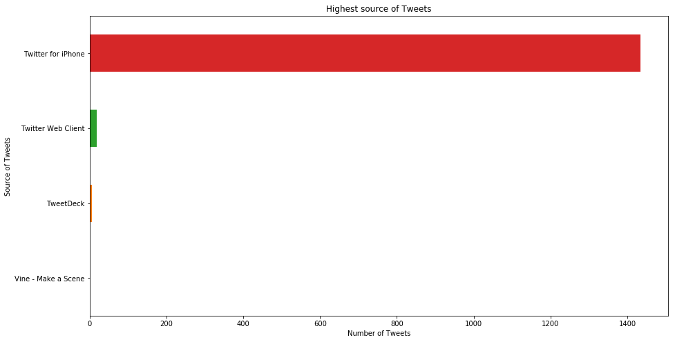

```python
plt.rcParams['figure.figsize'] = [15, 8]
(twitter.source.value_counts().sort_values()).plot(kind= 'barh')
plt.title('Highest source of Tweets')
plt.ylabel('Source of Tweets')
plt.xlabel('Number of Tweets')
plt.figure(figsize=(15,8));
```

#### The maximum number of tweets are coming from the source- Twitter for iPhone.

4) Which is the most popular dog rating ?

```python
dogs_vs_rating= twitter.rating.value_counts()
dogs_vs_rating
```

```
1.2    378
1.0    318
1.1    310
1.3    210
0.9    108
0.8     58
0.7     24
1.4     21
0.6     12
0.5     10
0.4      5
0.3      3
0.1      1
0.2      1
Name: rating, dtype: int64
```

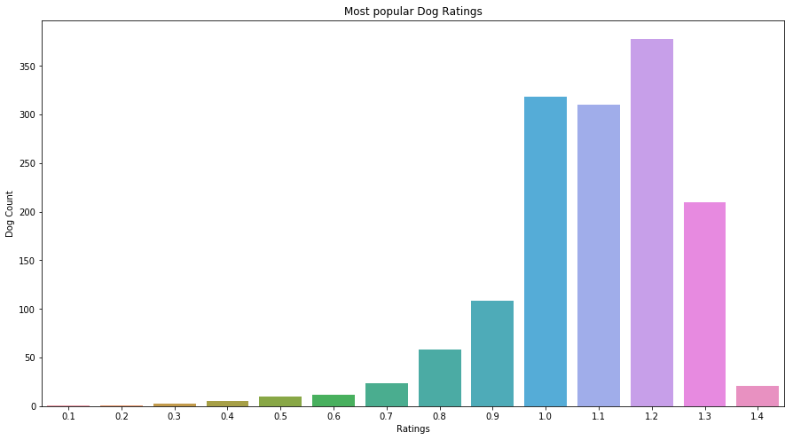

```python
sns.barplot(x= dogs_vs_rating.index, y= dogs_vs_rating.values)
plt.title('Most popular Dog Ratings')
plt.ylabel('Dog Count')
plt.xlabel('Ratings')
plt.figure(figsize=(15,8));
```

#### The plot clearly shows that 1.2 is the most popular dog rating with over 350 dogs rated so. This means that 12/10 is the most popular rating of WeRateDogs.

5) Which is the most predicted dog breed ?

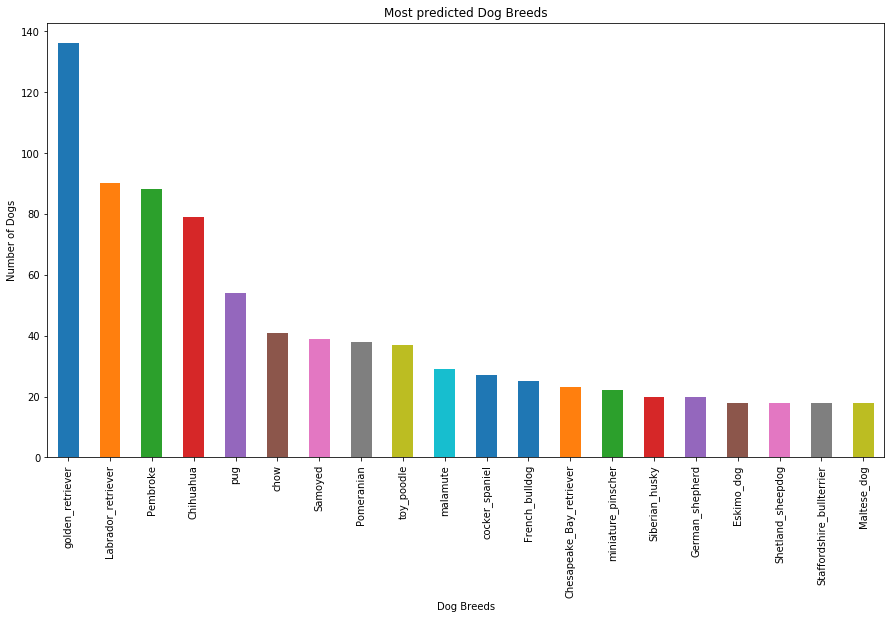

```python
(twitter.dog_breed_predicted.value_counts().head(20).sort_values(ascending= False)).plot(kind= 'bar')
plt.title('Most predicted Dog Breeds')
plt.ylabel('Number of Dogs')
plt.xlabel('Dog Breeds')
plt.figure(figsize=(15,8));
```

## Conclusions for the WeRateDogs Twitter account:-

- The dog stage 'doggo' wins the highest number of favorite counts as well as retweet counts.
- Twitter from iPhone is the source for maximum number of tweets.
- Rating of 1.2 (12/10) is the most popular dog rating.
- Golden Retriever is the most predicted dog breed.

## Resources include Google, Youtube, Stackoverflow and Python Documentation.

from subprocess import call call(['python', '-m', 'nbconvert', 'wrangle_act.ipynb'])